# Prédiction de l’histologie

Mélanie Veloso

2 décembre 2019

# Problématique

Le but de cet exercice est de parvenir à prédire l’histologie du cancer. Il s’agit de choisir le bon type de cancer entre un adénocarcinome du poumon et un carcinome épidermoïde du poumon. Pour cela, nous avons à notre disposition différentes informations :

- biologiques : age, sexe et l’histologie
- cliniques : os_months, dead, dead_at_24_months, t, n, m, tnm_stage, tnm_grade
- génétiques : 1000 gènes

Nous allons donc commencer par étudier ces variables. Nous poursuivrons ensuite avec la mise en place d’un modèle de régression logistique pour répondre à notre problème.

# Statistiques descriptives

```r
str(d[,1:4])
```

```
## 'data.frame':    546 obs. of  4 variables:
##  $ age          : num  62.3 82 60.6 46.9 60 ...
##  $ sex          : Factor w/ 2 levels "F","M": 1 2 2 1 2 1 1 2 2 1 ...
##  $ tissue_status: Factor w/ 1 level "tumoral": 1 1 1 1 1 1 1 1 1 1 ...
##  $ histology    : Factor w/ 2 levels "TCGA-LUAD","TCGA-LUSC": 1 1 1 1 1 1 1 1 1 1 ...
```

```r
table(is.na(d[,1:4]))
```

```
##
## FALSE
##  2184
```

Concernant les données biologiques nous n’observons aucune donnée manquante. De plus, tous les tissus que nous observons sont tumoraux. Nous avons donc uniquement des patients atteints de cancer.

```r
str(d[,5:12])
```

```
## 'data.frame':    546 obs. of  8 variables:
##  $ os_months        : Factor w/ 467 levels "0","0.03","0.07",..: 203 211 244 236 231 195 64 261 56 28 ...
##  $ dead             : Factor w/ 2 levels "false","true": 1 1 1 1 2 1 2 1 1 1 ...
##  $ dead_at_24_months: Factor w/ 2 levels "false","true": NA NA NA NA 2 NA 2 1 NA NA ...
##  $ t                : Factor w/ 9 levels "T1","T1a","T1b",..: 1 5 3 7 4 4 4 4 4 5 ...
##  $ n                : Factor w/ 5 levels "N0","N1","N2",..: 1 1 1 1 2 1 3 1 2 1 ...
##  $ m                : Factor w/ 5 levels "M0","M1","M1a",..: 1 1 1 5 1 1 1 1 1 1 ...
##  $ tnm_stage        : Factor w/ 10 levels "I","IA","IB",..: 2 3 2 6 6 3 8 3 6 3 ...
##  $ tnm_grade        : Factor w/ 0 levels: NA NA NA NA NA NA NA NA NA NA ...
```

Les données cliniques présentent des valeurs manquantes pour différentes variables :

```r
na_col <- sapply(c(5:12), function(x) sum(is.na(d[,x])))
names(na_col) <- colnames(d)[5:12]
na_col
```

```
##         os_months              dead dead_at_24_months                 t
##                 0                 0               203                 0
##                 n                 m         tnm_stage         tnm_grade
##                 1                 6                10               546
```

Pour certains patients nous n’avons plus l’information 24 mois après leur entrer dans l’étude. On peut supposer que les autres données manquantes n’étaient pas disponibles lors de l’étude.

```r
head(d[,13:19])
```

```
##                  MIR107  CT45A10   ATP10B   TMEM134    EMC10   FAHD2B      QKI
## TCGA-44-6145-01A      0 0.000000 9.142144  9.828997 12.74699 7.666713 12.58464
## TCGA-97-A4LX-01A      0 0.000000 7.770147 10.636394 12.57915 7.860443 12.43123
## TCGA-44-6148-01A      0 0.000000 5.380969  9.944632 12.66136 8.503297 12.02774
## TCGA-49-6767-01A      0 0.000000 4.365922 11.479250 12.25912 8.065132 12.40125
## TCGA-78-7150-01A      0 5.097967 6.610623  9.472286 13.22544 9.140085 11.68324
## TCGA-67-3772-01A      0 0.000000 8.747167 11.360779 13.59531 8.223864 12.13212
```

```r
table(is.na(d[,13:1012]))
```

```
##
##  FALSE
## 546000
```

Enfin les niveaux d’expression des gènes ne présentent pas de valeurs manquantes.

Nous nous intéressons à la variable que nous voulons prédire :

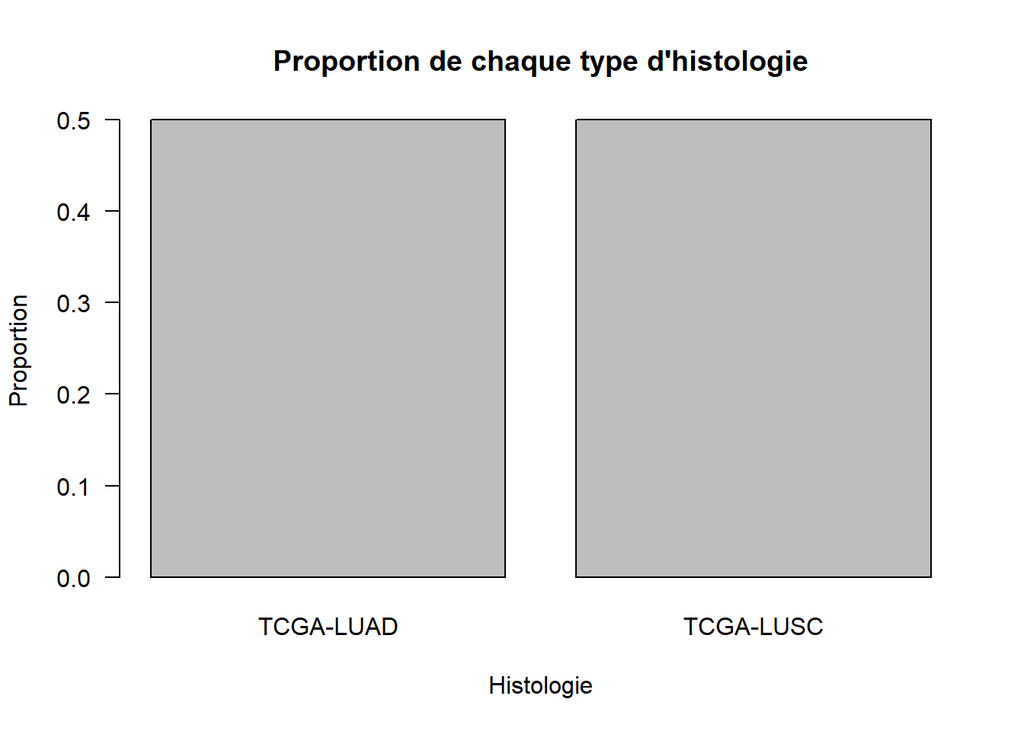

L’échantillon que nous avons présente autant de type d’histologie *TCGA-LUAD* que de type *TCGA-LUSC*. Cela nous permet d’avoir un cadre équilibrer.

Grâce à cette première étude on peut savoir plusieurs choses :

- La variable *tissue_status* ne nous aidera pas dans notre prédiction. Elle prend toujours la même valeur.
- La variable *tnm_grade* ne contient que des valeurs manquantes. Elle ne sera pas utilisée non plus dans les prédictions.

# Méthodes utilisées

A présent nous allons utiliser différentes approches afin de prédire l’histologie d’un patient à partir d’autres informations.

Afin de prédire l’histologie du cancer, nous allons utiliser un modèle de régression logistique. En effet, dans notre jeu de données l’histologie est binaire : *TCGA-LUAD* ou *TCGA-LUSC*.

Pour parvenir à trouver le meilleur modèle nous allons avoir différentes approches.

Tout d’abord, nous cherchons les variables les “plus intéressantes”. Pour cela nous aurons deux approches :

- Faire un modèle à une seule variable et récupéré celles dont le coefficient est relativement le plus significatif
- Observer les corrélations entre l’expression des gênes et la variable à prédire

Concernant le choix du modèle on utilisera 2 méthodes différentes. La première consiste à utiliser un test de vraisemblance entre un modèle et un autre modèle plus complet. Le but étant de trouver la variable à partir de laquelle le modèle plus complet n’est plus intéressant (coefficient de la variable supplémentaire non significatif). La seconde est une méthode de sélection de variable en utilisant un stepwise (permet de retirer et d’ajouter les variables au fur et à mesure des tests).

La prochaine partie, présente donc ces 2 grandes étapes (tri des variables et sélection de modèle).

# Evaluation critique de l’évolution du score

## Significativité des coefficients des variables

Pour commencer, on créé des modèles avec 1 seule variable et on enregistre la pvaleur du test de significativité du coefficient de la variable concernée.  
Cela nous permettra ensuite de comparer de façon relative la significativité des coefficients.

```r
# Récupération des noms de gènes
gs <- names(d)[13:1012]

# Varia
histo <- as.numeric(d$histology == "TCGA-LUAD")

# Calcul des pvaleurs des coefficients pour les gènes
res <- sapply(gs, function(g) {
  m = glm(c(histo,0,0,1,1)~c(d[[g]],0,max(d[,gs]),0,max(d[,gs])),
    family = binomial(logit))
  b = m$coefficients[[2]]
  pv = summary(m)$coefficients[2,4]
  c(pval = pv,beta = b)
})

# Calcul des pvaleur des coefficients pour les auters variables
res_bis <- sapply(c(c(1,2),c(5:11)), function(g) {
  m = glm(histo~d[[g]],
    family = binomial(logit))
  b = m$coefficients[[2]]
  pv = summary(m)$coefficients[2,4]
  c(pval = pv,beta = b)
})

# Mise en forme de toutes les pvaleurs
colnames(res_bis) <- colnames(d[,c(c(1,2),c(5:11))])
res <- cbind(res,res_bis)
res <- t(res)
res <- as.data.frame(res)
head(res)
```

```
##                 pval         beta
## MIR107  9.644035e-01 -0.003028164
## CT45A10 3.353450e-12 -0.262419324
## ATP10B  2.530902e-01  0.042087232
## TMEM134 1.751987e-06 -0.624654516
## EMC10   7.866760e-01 -0.020734017
## FAHD2B  6.254652e-06 -0.453096992
```

Nous pouvons maintenant représenter les résultats obtenus par tous ces modèles :

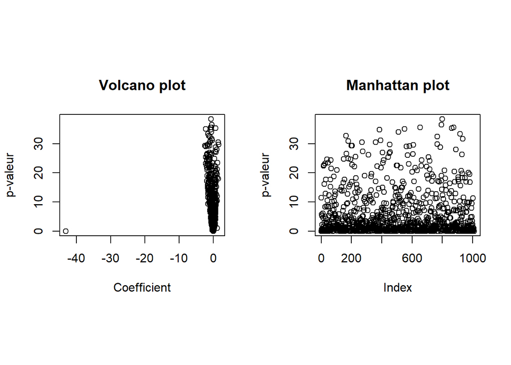

Sur le Volcano plot, on remarque quelques p-valeurs qui “s’échappent” vers le haut. Il s’agit des variables dont les coefficients sont les plus significatifs relativement aux autres. La même observation peut-être faite sur le Manhattan plot.  
On observe aussi un coefficient qui se distingue des autres de par sa valeur. En effet, il vaut -43.13 et correspond à la variable os_months.  
On rappelle que dans notre cas, si le coefficient est négatif il y a de faibles valeurs pour le groupe *TCGA-LUAD* et de grandes valeurs pour le groupe *TCGA-LUSC*. Cette variable ne semble tout de même pas pertinente. En effet, son coefficient ne semble pas être significatif relativement à ceux des autres variables.

### Modèle à 1 seule variable

A présent, nous sélectionnons uniquement la variable pour laquelle nous avons obtenu la p-valeur la plus faible. Il s’agit donc du modèle suivant :

$$\begin{align*}
histology \sim \beta_1 LINC02428 \\
\end{align*}$$

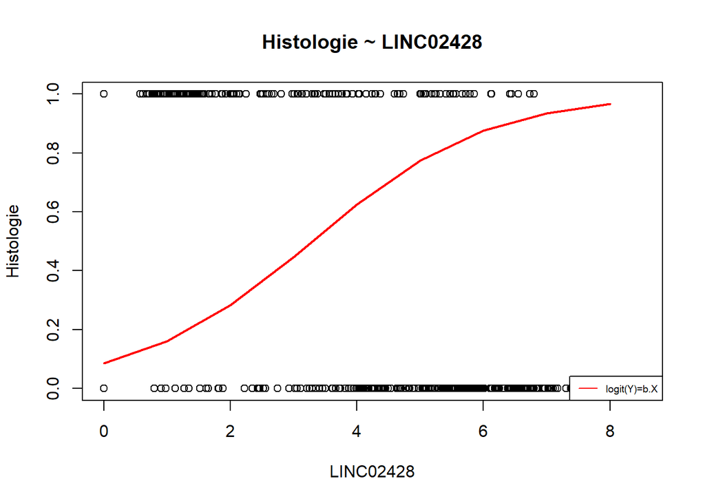

```r
# rownames(res)[order(res$pval)][1]

# Méthode avec la meilleure variable 0.8
mod_1 <- glm(
    formula = histology ~ LINC02428,
    data = d,
    family = binomial(link = 'logit')
)
```

Sur le graphique, on peut donc voir que le groupe *TCGA-LUSC* a une expression plutôt forte du gène *LINC02428* contrairement au groupe *TCGA-LUAD*.

Ce modèle avec une seule variable nous permet d’obtenir un score de 0.8 sur Codalab.

### Méthode utilisant le test de vraisemblance

Afin d’améliorer nos prédictions nous allons essayer de compléter notre modèle en utilisant un test de vraisemblance.  
Pour cela on rajoute au fur et à mesure les meilleures variables obtenues précédemment en termes de significativité et on procède à un test de vraisemblance entre les 2 modèles.  
On s’arrête lorsque l’ajout d’une nouvelle variable n’est pas pertinent. On obtient alors le modèle suivant :

$$\begin{align*}
histology \sim \beta_1 LINC02428 + \beta_2 DLX6 + \beta_3 KRT42P + \beta_4 SERPINB2 + \beta_5 SPDEF + \\ \beta_6 TMEM189 + \beta_7 CDHR1 + \beta_8 SERPINB5 + \beta_9 MCM2 + \beta_{10} LINC01503
\end{align*}$$

```r
# Méthode test de vraisemblance 0.51
mod_1 <- glm(
    formula = histology ~ LINC02428 + DLX6 + KRT42P + SERPINB2 + SPDEF + TMEM189 + CDHR1 + SERPINB5 + MCM2 + LINC01503,
    data = d,
    family = binomial(link = 'logit')
)

mod_2 <- glm(
    formula = histology ~ LINC02428 + DLX6 + KRT42P + SERPINB2 + SPDEF + TMEM189 + CDHR1 + SERPINB5 + MCM2 + LINC01503 + SMO,
    data = d,
    family = binomial(link = 'logit')
)

# Test de vraisemblance
anova(mod_1,mod_2,test = "Chisq")
```

```
## Analysis of Deviance Table
##
## Model 1: histology ~ LINC02428 + DLX6 + KRT42P + SERPINB2 + SPDEF + TMEM189 +
##     CDHR1 + SERPINB5 + MCM2 + LINC01503
## Model 2: histology ~ LINC02428 + DLX6 + KRT42P + SERPINB2 + SPDEF + TMEM189 +
##     CDHR1 + SERPINB5 + MCM2 + LINC01503 + SMO
##   Resid. Df Resid. Dev Df Deviance Pr(>Chi)
## 1       535     126.20
## 2       534     126.18  1 0.019464    0.889
```

Ce modèle nous permet d’obtenir un score de 0.51 sur Codalab.  
On peut donc soupçonner un sur-apprentissage sur les données d’entrainement. On ne parvient plus à faire de bonnes prédictions sur les données de test car le modèle est trop adapté aux données d’entrainement.

### Méthode utilisant un stepwise

La méthode précédente n’étant pas très concluante nous essayons une méthode différente. Nous allons donc sélectionner les 20 meilleures variables et utiliser un stepwise. On commence donc avec un modèle composé uniquement d’une constante et on vient ensuite ajouter et retirer certaines variables.

```r
# Méthode par step 0.92
var <- rownames(res)[order(res$pval)]
var <- paste("~ ",paste(paste0("d$",var[1:20]), collapse= "+"))

m0 = glm(
    formula = histo ~ 1
  , family = binomial(link = 'logit')
)

step_20 <- step(m0,scope = var,direction = "both")
```

```r
summary(step_20)
```

```
##
## Call:
## glm(formula = histo ~ d$TMEM189 + d$CDHR1 + d$MCM2 + d$SERPINB2 +
##     d$SNCA + d$LINC01503 + d$KRT33A + d$SPDEF + d$SERPINB5 +
##     d$FBL, family = binomial(link = "logit"))
##
## Deviance Residuals:
##     Min       1Q   Median       3Q      Max
## -2.3333  -0.0267   0.0009   0.0894   4.0036
##
## Coefficients:
##             Estimate Std. Error z value Pr(>|z|)
## (Intercept)  47.1672     8.5137   5.540 3.02e-08 ***
## d$TMEM189    -1.1798     0.5002  -2.359 0.018349 *
## d$CDHR1      -0.6419     0.1741  -3.687 0.000227 ***
## d$MCM2       -0.8153     0.3535  -2.307 0.021072 *
## d$SERPINB2   -0.2480     0.1043  -2.377 0.017435 *
## d$SNCA       -0.5194     0.1932  -2.689 0.007176 **
## d$LINC01503  -0.8240     0.2510  -3.283 0.001027 **
## d$KRT33A      0.6726     0.1851   3.634 0.000279 ***
## d$SPDEF       0.4728     0.1305   3.622 0.000293 ***
## d$SERPINB5   -0.2773     0.1025  -2.706 0.006804 **
## d$FBL        -0.8350     0.4713  -1.772 0.076420 .
## ---
## Signif. codes:  0 '***' 0.001 '**' 0.01 '*' 0.05 '.' 0.1 ' ' 1
##
## (Dispersion parameter for binomial family taken to be 1)
##
##     Null deviance: 756.92  on 545  degrees of freedom
## Residual deviance: 105.09  on 535  degrees of freedom
## AIC: 127.09
##
## Number of Fisher Scoring iterations: 8
```

Nous retenons alors le modèle suivant :

$$\begin{align*}
histology \sim \beta_1 TMEM189 + \beta_2 CDHR1 + \beta_3 MCM2 + \beta_4 SERPINB2 + \\ \beta_5
SNCA + \beta_6 LINC01503 + \beta_7 KRT33A + \beta_8 SPDEF + \beta_9 SERPINB5 + \beta_{10}
FBL \\
\end{align*}$$

Cette approche nous permet d’obtenir un score de 0.92 sur Codalab.

Afin de vérifier si nous ne pouvons pas obtenir de meilleures prédictions nous allons maintenant considérer plus de variables au départ (60).

```r
# Méthode par step 0.5
var <- rownames(res)[order(res$pval)]
var <- paste("~ ",paste(paste0("d$",var[1:60]), collapse= "+"))

m0 = glm(
    formula = histo ~ 1
  , family = binomial(link = 'logit')
)

step_60 <- step(m0,scope = var,direction = "both")
```

```r
summary(step_60)
```

```
##
## Call:
## glm(formula = histo ~ d$WDPCP + d$CSK + d$CDHR1 + d$UFD1 + d$LINC01503 +
##     d$KRT33A + d$SERPINB5 + d$SPDEF + d$LRRN4 + d$BBOX1 + d$H2AFZ +
##     d$JUP + d$KRT42P + d$GSK3B + d$H2AFY2 + d$KPNA1 + d$ARHGAP23 +
##     d$HSPB1 + d$FOXL2 + d$CCAT1 + d$NDUFB5, family = binomial(link = "logit"))
##
## Deviance Residuals:
##        Min          1Q      Median          3Q         Max
## -2.334e-03  -2.000e-08   0.000e+00   2.000e-08   2.284e-03
##
## Coefficients:
##               Estimate Std. Error z value Pr(>|z|)
## (Intercept)  125566.34 5010911.82   0.025    0.980
## d$WDPCP       -4164.34  148190.13  -0.028    0.978
## d$CSK          -781.62   68633.38  -0.011    0.991
## d$CDHR1       -1065.23   40227.47  -0.026    0.979
## d$UFD1        -3037.56  147157.89  -0.021    0.984
## d$LINC01503    -875.05   52132.46  -0.017    0.987
## d$KRT33A        725.03   21285.61   0.034    0.973
## d$SERPINB5     -163.74   12199.93  -0.013    0.989
## d$SPDEF         319.20   11913.62   0.027    0.979
## d$LRRN4         -87.88     831.15  -0.106    0.916
## d$BBOX1         249.23   17864.26   0.014    0.989
## d$H2AFZ       -1958.23   30722.47  -0.064    0.949
## d$JUP         -2014.35   83344.23  -0.024    0.981
## d$KRT42P        334.28   14533.02   0.023    0.982
## d$GSK3B        3241.57  116503.85   0.028    0.978
## d$H2AFY2       -568.78   25234.94  -0.023    0.982
## d$KPNA1       -2801.67  117631.67  -0.024    0.981
## d$ARHGAP23     -828.85   16837.79  -0.049    0.961
## d$HSPB1         926.78   52860.69   0.018    0.986
## d$FOXL2         314.67   16678.67   0.019    0.985
## d$CCAT1         233.21   12970.04   0.018    0.986
## d$NDUFB5        869.07   27519.54   0.032    0.975
##
## (Dispersion parameter for binomial family taken to be 1)
##
##     Null deviance: 7.5692e+02  on 545  degrees of freedom
## Residual deviance: 5.1651e-05  on 524  degrees of freedom
## AIC: 44
##
## Number of Fisher Scoring iterations: 25
```

Cela nous permet d’obtenir le modèle suivant :

$$\begin{align*}
histology \sim \beta_1 WDPCP + \beta_2 CSK + \beta_3 CDHR1 + \beta_4 UFD1 + \beta_5 LINC01503 + \\ \beta_6
KRT33A + \beta_7 SERPINB5 + \beta_8 SPDEF + \beta_9 LRRN4 + \beta_{10} BBOX1 + \\ \beta_{11} H2AFZ + \beta_{12}
JUP + \beta_{13} KRT42P + \beta_{14} GSK3B + \beta_{15} H2AFY2 + \\ \beta_{16} KPNA1 + \beta_{17} ARHGAP23 + \beta_{18}
HSPB1 + \beta_{19} FOXL2 + \\ \beta_{20} CCAT1 + \beta_{21} NDUFB5
\end{align*}$$

Contrairement à nos attentes, ce modèle ne nous permet pas de faire de meilleures prédictions. En effet, nous obtenons un score de 0.5 sur Codalab. Comme vu précédemment il peut s’agir d’un effet de sur-apprentissage sur les données d’entrainement.

## Corrélations entre l’histologie et l’expression des gênes

A présent nous tentons une approche différente pour sélectionner les variables au départ. Pour cela nous allons calculer les corrélations entre la variable à prédire (histologie) et l’expression de tous les gènes. Nous obtenons alors une nouvelle sélection. Nous choisissons ensuite de nous intéresser uniquement aux variables dont la corrélation est supérieure à $0.65$ en valeur absolue.

```r
# Méthode de la correlation
correlation <- abs(cor(histo,d[,gs]))
var_cor <- na.omit(gs[correlation>0.65])
```

Nous avons ensuite recours à un stepwise pour sélectionner le meilleur modèle possible.  
Nous obtenons alors :

$$\begin{align*}
histology \sim \beta_1 TMEM189 + \beta_2 WDPCP + \beta_3 CDHR1 + \beta_4 SERPINB5 + \beta_5
SPDEF + \\ \beta_6 LINC01503 + \beta_7 KRT33A + \beta_8 MCM2 + \beta_9 SERPINB2 + \\ \beta_{10}
KPNA1 + \beta_{11} KRT42P
\end{align*}$$

```r
# Méthode par step 0.92
var_cor <- paste("~ ",paste(paste0("d$",var_cor), collapse= "+"))

m0 = glm(
    formula = histo ~ 1
  , family = binomial(link = 'logit')
)

step_var_cor <- step(m0,scope = var_cor,direction = "both")
```

```r
summary(step_var_cor)
```

```
##
## Call:
## glm(formula = histo ~ d$TMEM189 + d$WDPCP + d$CDHR1 + d$SERPINB5 +
##     d$SPDEF + d$LINC01503 + d$KRT33A + d$MCM2 + d$SERPINB2 +
##     d$KPNA1 + d$KRT42P, family = binomial(link = "logit"))
##
## Deviance Residuals:
##     Min       1Q   Median       3Q      Max
## -2.4166  -0.0163   0.0010   0.0792   4.5660
##
## Coefficients:
##             Estimate Std. Error z value Pr(>|z|)
## (Intercept) 70.13580   13.13536   5.339 9.32e-08 ***
## d$TMEM189   -1.64003    0.50850  -3.225 0.001259 **
## d$WDPCP     -2.13443    0.63851  -3.343 0.000829 ***
## d$CDHR1     -0.89071    0.20373  -4.372 1.23e-05 ***
## d$SERPINB5  -0.27497    0.09787  -2.809 0.004963 **
## d$SPDEF      0.40697    0.13187   3.086 0.002028 **
## d$LINC01503 -1.02346    0.28628  -3.575 0.000350 ***
## d$KRT33A     0.87411    0.20892   4.184 2.86e-05 ***
## d$MCM2      -0.68262    0.30907  -2.209 0.027202 *
## d$SERPINB2  -0.30629    0.11610  -2.638 0.008333 **
## d$KPNA1     -1.22734    0.74795  -1.641 0.100809
## d$KRT42P     0.23456    0.16264   1.442 0.149249
## ---
## Signif. codes:  0 '***' 0.001 '**' 0.01 '*' 0.05 '.' 0.1 ' ' 1
##
## (Dispersion parameter for binomial family taken to be 1)
##
##     Null deviance: 756.917  on 545  degrees of freedom
## Residual deviance:  98.317  on 534  degrees of freedom
## AIC: 122.32
##
## Number of Fisher Scoring iterations: 9
```

Grâce à cette méthode, nous obtenons un score de 0.92 sur Codalab. Nous avons donc 2 modèles différents avec un score identique. Dans la partie suivante nous tenterons d’expliquer pourquoi ces modèles sont pertinents.

# Discussion et interprétation

Grâce à nos différentes méthodes, nous retenons donc 2 modèles :

$$\begin{align*}
histology \sim \beta_1 TMEM189 + \beta_2 WDPCP + \beta_3 CDHR1 + \beta_4 SERPINB5 + \beta_5
SPDEF + \\ \beta_6 LINC01503 + \beta_7 KRT33A + \beta_8 MCM2 + \beta_9 SERPINB2 + \\ \beta_{10}
KPNA1 + \beta_{11} KRT42P
\end{align*}$$
$$\begin{align*}
histology \sim \beta_1 TMEM189 + \beta_2 CDHR1 + \beta_3 MCM2 + \beta_4 SERPINB2 + \\ \beta_5
SNCA + \beta_6 LINC01503 + \beta_7 KRT33A + \beta_8 SPDEF + \beta_9 SERPINB5 + \beta_{10}
FBL \\
\end{align*}$$

Dans un premier temps, il n’est pas étonnant de voir que le gène *LINC01503* est important. En effet, son expression s’associe à la présence d’un carcinome épidermoïde ce qui est l’une des deux histologies auxquelles nous nous intéressons.  
Le gène *CDHR1* est lui associé à des dystrophies Cone-Rod et fondamentales. Ces maladies peuvent être observé dans certains cas de carcinome épidermoïde du poumon.  
Le gène *SERPINB5* s’exprime lui lorsqu’un carcinome osseux est observé ce qui n’est pas notre cas. Cependant, on peut se demander si l’expression de ce gène n’est pas aussi liée au carcinome épidermoïde du poumon ?

Les variables retenues dans ces 2 modèles ne sont pas dénuées de sens au regard de ce que nous cherchons à prédire. En effet, nous avons pu voir qu’il s’agissait de gène s’exprimant lors de la présence de certaines maladies en lien direct ou indirect avec les histologies que nous avons observé. De plus les 2 modèles retenus contiennent beaucoup de variables en commun ce qui explique certainement l’obtention d’un score identique.